# PEC_3_SAD

Joel Calero Rodriguez y Manuel Rosario Marín Fernández

27/12/2021

## Apartado 1

#### Buscar un conjunto de datos relacionados con la Bioestadística o la Bioinformática. Será necesario especificar la procedencia y la justificación de la elección de los datos.

#### 1.1 - Estudiar la respuesta inmunologica innata ex vivo en dos poblaciones de macrofagos (bazo y peritoneo) frente a diferentes antigenos del tratamiento. Las muestras fueron tomadas del modelo murino que recibieron el tratamiento alternativo (A) y el de referencia (B). Para estudiar el efecto del tumor en la respuesta innata, tambien se le suministro el tratamiento A y B en animales sin cancer.

- ¿A que antigeno responden mas los macrofagos?
- ¿Responden los macrofagos a los mismos antigenos que se encuentran en el peritoneo y en el bazo?
- ¿La presencia de tumor en los animales modifica la respuesta a los distintos antigenos?

##### - A: Tratamiento A con tumor

##### - B: Tratamiento A sin tumor

##### - C: Tratamiento B con tumor

##### - D: Tratamiento B sin tumor

##### - I: Animal control con tumor

##### - J: Animal control sin tumor:

## Apartado 2

#### Utilizando R, mostrar y explicar qué tipo de ficheros se han importado, las variables de estudio (tipo, clasificación, …), así como todo aquello relevante para el estudio. Incluir capturas de pantalla y las instrucciones en R utilizadas para importar y mostrar los datos.

```r
head(dataMurine) # Mostrar datos
```

```
##   Raton Grupo    Region Antigeno Reestimulacion
## 1     1     A Peritoneo        1       87.80488
## 2     2     A Peritoneo        1      110.97561
## 3     3     A Peritoneo        1       95.01661
## 4     4     A Peritoneo        1       81.72757
## 5     5     A Peritoneo        1       89.35185
## 6     6     A Peritoneo        1      129.47976
```

```r
summary(dataMurine) # Significado de cada variable
```

```
##      Raton           Grupo              Region             Antigeno
##  Min.   : 1.000   Length:1368        Length:1368        Min.   :1
##  1st Qu.: 4.000   Class :character   Class :character   1st Qu.:3
##  Median : 7.000   Mode  :character   Mode  :character   Median :5
##  Mean   : 7.204                                         Mean   :5
##  3rd Qu.:10.000                                         3rd Qu.:7
##  Max.   :18.000                                         Max.   :9
##
##  Reestimulacion
##  Min.   : 10.59
##  1st Qu.: 93.49
##  Median :110.16
##  Mean   :115.18
##  3rd Qu.:129.23
##  Max.   :397.26
##  NA's   :27
```

```r
str(dataMurine) # Tipo de valores de cada variable
```

```
## 'data.frame':    1368 obs. of  5 variables:
##  $ Raton         : int  1 2 3 4 5 6 7 8 9 10 ...
##  $ Grupo         : chr  "A" "A" "A" "A" ...
##  $ Region        : chr  "Peritoneo" "Peritoneo" "Peritoneo" "Peritoneo" ...
##  $ Antigeno      : int  1 1 1 1 1 1 1 1 1 1 ...
##  $ Reestimulacion: num  87.8 111 95 81.7 89.4 ...
```

```r
## Dar nombre a los grupos para facilitar la comprension
groupNames <- factor(dataMurine$Grupo, levels = c("A","B","C","D","I","J"),labels = c("Tratamiento A con tumor","Tratamiento A sin tumor","Tratamiento B con tumor","Tratamiento B sin tumor","Animal control con tumor","Animal control sin tumor") )
unique(groupNames) ## Comprobar que los labels estan introducidos correctamente
```

```
## [1] Tratamiento A con tumor  Tratamiento A sin tumor  Tratamiento B con tumor
## [4] Tratamiento B sin tumor  Animal control con tumor Animal control sin tumor
## 6 Levels: Tratamiento A con tumor ... Animal control sin tumor
```

## Apartado 3

#### Con la Sección 2 de la PEC1 como base, elaborar y analizar una serie de cuestiones, que ayuden a explorar y a familiarizarse mejor con los datos de estudio. Además, en algunos casos, puede utilizarse la definición de funciones y el lenguaje SQL estudiado en el LAB3.

#### 3.1 - ¿Cuantos valores N/A se encuentran en la Base de Datos?

```r
cat("Existen un total de",table(!is.na(dataMurine))["FALSE"],"valores N/A en la base de datos") # Contar valores N/A
```

```
## Existen un total de 27 valores N/A en la base de datos
```

#### 3.2 - A partir de un nuevo frame con solamente el grupo A (Tratamiento A con tumor) y de la region Peritoneo, Que media de reestimulacion es superior?

```r
dataMurineA <- subset(dataMurine,(dataMurine$Grupo =="A" & dataMurine$Region == "Peritoneo"))
dataMurineA <- na.omit(dataMurineA) #Eliminar valores N/A
aggregate(dataMurineA$Reestimulacion, list(dataMurineA$Antigeno), FUN=mean)
```

```
##   Group.1         x
## 1       1 107.09066
## 2       2 103.01911
## 3       3 116.51495
## 4       4  80.86163
## 5       5  83.56580
## 6       6  88.14081
## 7       7  95.42732
## 8       8 142.39061
## 9       9 104.09442
```

```r
#Eliminar valores N/A
dataMurine <- na.omit(dataMurine)
```

#### 3.3 - Crear una funcion que dado un grupo, una región, un antigeno, escriba en un csv junto con la informacion de entrada, la media, mediana, desviacion estandard y los valores maximos minimos.

```r
functionSummary <- function(NumGrupo,NumRegion,NumAntigeno){
  resultPath <- c(getwd(),"/","Output_PEC3.csv") ## Leer ruta para cargar base de datos
  resultFile <- paste0(resultPath,collapse = "")
  resultFile
  if (file.exists(resultFile) == FALSE){
    file.create(resultFile)
    values0 <- c("Grupo","Region","Antigeno","Media","Mediana","St.Dev","Max","Min")

    write.table(as.list(values0), file = resultFile ,col.names = FALSE, append=TRUE,sep = ",",row.names = FALSE)
  }

  Num1 <- c(NumGrupo, NumRegion, NumAntigeno)
  newFrame <- subset(dataMurine,(dataMurine$Grupo == Num1[1] & dataMurine$Region == Num1[2] & dataMurine$Antigeno == Num1[3]))

  values1 <- c(NumGrupo,NumRegion,NumAntigeno,round(mean(newFrame$Reestimulacion),3),round(median(newFrame$Reestimulacion),3),round(sd(newFrame$Reestimulacion),3),round(max(newFrame$Reestimulacion),3),round(min(newFrame$Reestimulacion),3))
  write.table(as.list(values1), file = resultFile ,col.names = FALSE, append=TRUE,sep = ",",row.names = FALSE)
  values1

}

functionSummary("A","Peritoneo",1)
```

```
## [1] "A"         "Peritoneo" "1"         "107.091"   "110.976"   "16.333"
## [7] "129.48"    "81.728"
```

```r
#Guardamos una copia de los datos sin labels ni levels para posterior uso:
dataMurineBackup<-dataMurine
```

## Apartado 4

#### Realizar un análisis descriptivo de los datos. El análisis debe incluir (tal y como aparece en la Sección 3 de la PEC1) un resumen paramétrico de los datos y su representación gráfica, que mejor defina y complemente cada una de dichas variables.

#### 4.1 - Cambios de clase a ciertas variables para poder trabajar con ellas, de manera más clara

```r
dataMurine$Grupo <- factor(dataMurine$Grupo, levels = c("A","B","C","D","I","J"))
dataMurine$Region<- factor(dataMurine$Region,levels = c("Peritoneo", "Bazo"))
dataMurine$Antigeno <- as.factor(dataMurine$Antigeno)


summary(dataMurine) #resumen parametrico de las variables
```

```
##      Raton       Grupo         Region       Antigeno   Reestimulacion
##  Min.   : 1.00   A:204   Peritoneo:610   1      :151   Min.   : 10.59
##  1st Qu.: 4.00   B:234   Bazo     :731   2      :151   1st Qu.: 93.49
##  Median : 7.00   C:211                   3      :151   Median :110.16
##  Mean   : 7.28   D:216                   4      :151   Mean   :115.18
##  3rd Qu.:10.00   I:246                   5      :150   3rd Qu.:129.23
##  Max.   :18.00   J:230                   6      :150   Max.   :397.26
##                                          (Other):437
```

#### 4.2 - Representación de las diferentes variables:

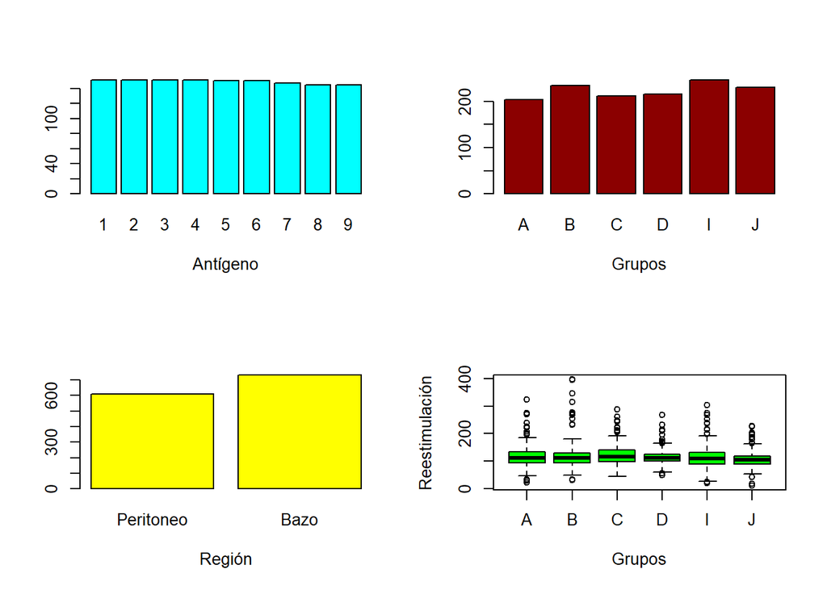

```r
par(mfrow=c(2,2))
plot(dataMurine$Antigeno, col = "cyan", xlab= "Antígeno") # el número de individuos por antigeno utilizado


plot(dataMurine$Grupo, col = "dark red", xlab= "Grupos") # el numero de individuos de cada grupo

plot(dataMurine$Region,col= "yellow", xlab= "Región") #el numero de individuos por región


plot(dataMurine$Grupo,dataMurine$Reestimulacion,type='o', col = "green", xlab= "Grupos", ylab= "Reestimulación") #la reestimulación por cada grupo del estudio
```

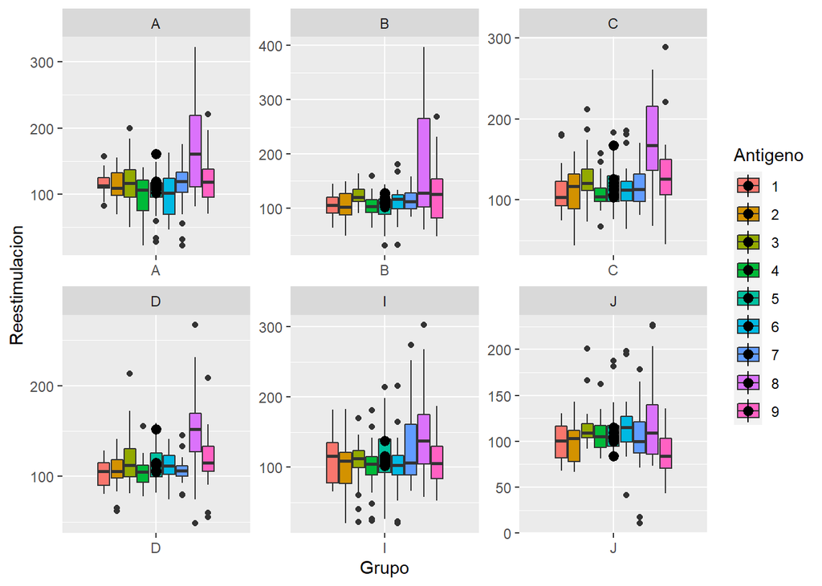

```r
# Boxplot con los valores de reestimulacion por grupo, agrupado por tipo de antigeno
library(ggplot2)

plotMurine <- ggplot(dataMurine, aes(x=Grupo, y=Reestimulacion,fill = Antigeno)) +
  geom_boxplot()+stat_summary(fun = median)
plotMurine + facet_wrap( ~ Grupo, scales="free")
```

#### 4.3 - Media por tratamientos (grupos A, B, C, D, I, J):

```
##                    Group.1        x
## 1  Tratamiento A con tumor 115.0638
## 2  Tratamiento A sin tumor 118.5086
## 3  Tratamiento B con tumor 122.9565
## 4  Tratamiento B sin tumor 114.5682
## 5 Animal control con tumor 113.8308
## 6 Animal control sin tumor 106.7699
```

## Apartado 5

#### Complementando el apartado anterior, elaborar un análisis de regresión de dos conjuntos de variables (LAB2 y Ejercicio 6 de la PEC1). La elección de las variables, los resultados, así como su relación deben de estar correctamente justificada.

### 5.1 - Analisis de regresión sobre las variables Reestimulacion y Region para ver si existe una relacion lineal entre ellos.

```r
str(dataMurine)
```

```
## 'data.frame':    1341 obs. of  5 variables:
##  $ Raton         : int  1 2 3 4 5 6 7 8 9 10 ...
##  $ Grupo         : Factor w/ 6 levels "Tratamiento A con tumor",..: 1 1 1 1 1 1 1 1 1 1 ...
##  $ Region        : Factor w/ 2 levels "Peritoneo","Bazo": 1 1 1 1 1 1 1 1 1 1 ...
##  $ Antigeno      : Factor w/ 9 levels "1","2","3","4",..: 1 1 1 1 1 1 1 1 1 1 ...
##  $ Reestimulacion: num  87.8 111 95 81.7 89.4 ...
##  - attr(*, "na.action")= 'omit' Named int [1:27] 40 110 180 250 302 320 372 390 425 442 ...
##   ..- attr(*, "names")= chr [1:27] "40" "110" "180" "250" ...
```

```r
summary(dataMurine)
```

```
##      Raton                            Grupo           Region       Antigeno
##  Min.   : 1.00   Tratamiento A con tumor :204   Peritoneo:610   1      :151
##  1st Qu.: 4.00   Tratamiento A sin tumor :234   Bazo     :731   2      :151
##  Median : 7.00   Tratamiento B con tumor :211                   3      :151
##  Mean   : 7.28   Tratamiento B sin tumor :216                   4      :151
##  3rd Qu.:10.00   Animal control con tumor:246                   5      :150
##  Max.   :18.00   Animal control sin tumor:230                   6      :150
##                                                                 (Other):437
##  Reestimulacion
##  Min.   : 10.59
##  1st Qu.: 93.49
##  Median :110.16
##  Mean   :115.18
##  3rd Qu.:129.23
##  Max.   :397.26
##
```

```r
dataMurineNumeric<-dataMurine
dataMurineNumeric$Grupo<-as.numeric(dataMurine$Grupo)
dataMurineNumeric$Region<-as.numeric(dataMurine$Region)
dataMurineNumeric$Antigeno<-as.numeric(dataMurine$Antigeno)
summary(dataMurineNumeric)
```

```
##      Raton           Grupo           Region         Antigeno
##  Min.   : 1.00   Min.   :1.000   Min.   :1.000   Min.   :1.000
##  1st Qu.: 4.00   1st Qu.:2.000   1st Qu.:1.000   1st Qu.:3.000
##  Median : 7.00   Median :4.000   Median :2.000   Median :5.000
##  Mean   : 7.28   Mean   :3.564   Mean   :1.545   Mean   :4.962
##  3rd Qu.:10.00   3rd Qu.:5.000   3rd Qu.:2.000   3rd Qu.:7.000
##  Max.   :18.00   Max.   :6.000   Max.   :2.000   Max.   :9.000
##  Reestimulacion
##  Min.   : 10.59
##  1st Qu.: 93.49
##  Median :110.16
##  Mean   :115.18
##  3rd Qu.:129.23
##  Max.   :397.26
```

```
##                      Grupo       Region     Antigeno Reestimulacion
## Grupo           1.00000000 -0.156525810 -0.005310840    -0.07926643
## Region         -0.15652581  1.000000000  0.002792134     0.30722088
## Antigeno       -0.00531084  0.002792134  1.000000000     0.19017387
## Reestimulacion -0.07926643  0.307220878  0.190173866     1.00000000
```

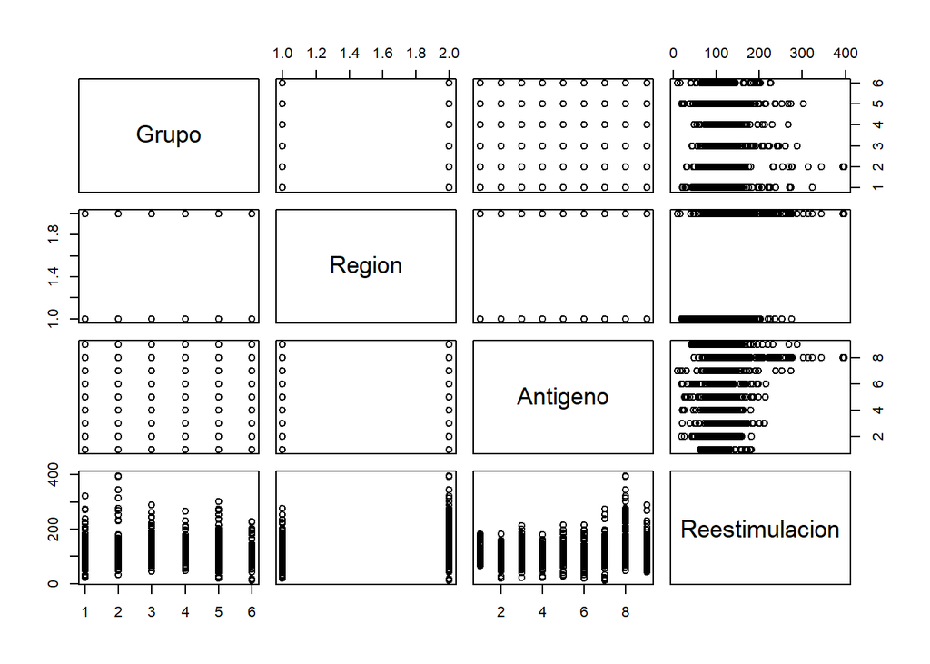

```r
cor(x=dataMurineNumeric[2:5],method="pearson"); pairs(dataMurineNumeric[2:5])
```

```r
# Tenemos en cuenta solo las variables no los IDs de los ratones ya que no aportan nada ahora mismo
```

### 5.2 - Regresión lineal

```r
murine_rl=lm(formula= Reestimulacion~Region,data=dataMurineNumeric[2:5])
summary(murine_rl)
```

```
##
## Call:
## lm(formula = Reestimulacion ~ Region, data = dataMurineNumeric[2:5])
##
## Residuals:
##      Min       1Q   Median       3Q      Max
## -115.946  -21.828   -6.394   13.466  270.726
##
## Coefficients:
##             Estimate Std. Error t value Pr(>|t|)
## (Intercept)   76.606      3.431   22.33   <2e-16 ***
## Region        24.964      2.113   11.81   <2e-16 ***
## ---
## Signif. codes:  0 '***' 0.001 '**' 0.01 '*' 0.05 '.' 0.1 ' ' 1
##
## Residual standard error: 38.54 on 1339 degrees of freedom
## Multiple R-squared:  0.09438,    Adjusted R-squared:  0.09371
## F-statistic: 139.6 on 1 and 1339 DF,  p-value: < 2.2e-16
```

#### 5.2.1 - Representación del conjunto de variables:

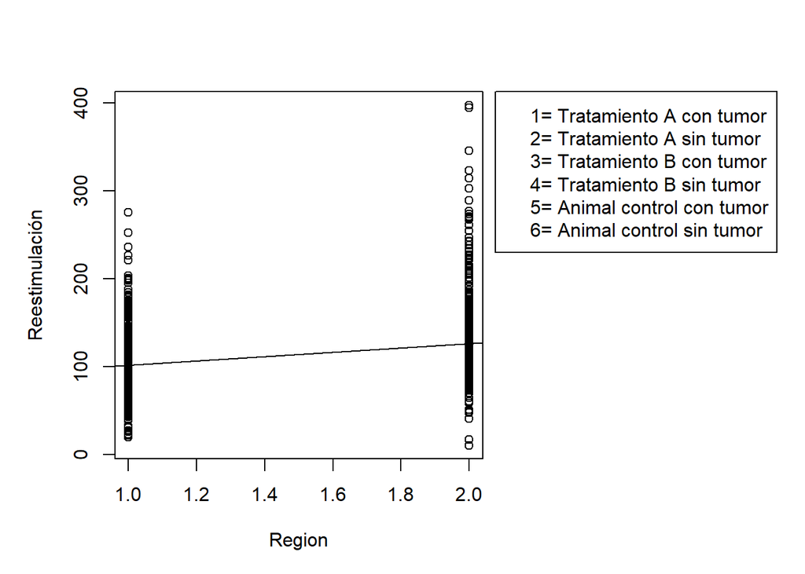

### 5.3 - Regresión multiple

```r
murine_rm<-lm(dataMurineNumeric$Reestimulacion~dataMurineNumeric$Region + dataMurineNumeric$Grupo+dataMurineNumeric$Antigeno,data=dataMurineNumeric[2:5])
summary(murine_rm)
```

```
##
## Call:
## lm(formula = dataMurineNumeric$Reestimulacion ~ dataMurineNumeric$Region +
##     dataMurineNumeric$Grupo + dataMurineNumeric$Antigeno, data = dataMurineNumeric[2:5])
##
## Residuals:
##      Min       1Q   Median       3Q      Max
## -120.011  -21.074   -5.211   14.714  260.742
##
## Coefficients:
##                            Estimate Std. Error t value Pr(>|t|)
## (Intercept)                 65.1562     4.7455  13.730  < 2e-16 ***
## dataMurineNumeric$Region    24.5268     2.0973  11.695  < 2e-16 ***
## dataMurineNumeric$Grupo     -0.7365     0.6129  -1.202     0.23
## dataMurineNumeric$Antigeno   2.9726     0.4006   7.421 2.07e-13 ***
## ---
## Signif. codes:  0 '***' 0.001 '**' 0.01 '*' 0.05 '.' 0.1 ' ' 1
##
## Residual standard error: 37.77 on 1337 degrees of freedom
## Multiple R-squared:  0.1312, Adjusted R-squared:  0.1292
## F-statistic: 67.28 on 3 and 1337 DF,  p-value: < 2.2e-16
```

#### 5.3.1 -Análisis de los mejores predictores

```r
step(object=murine_rm,direction ="both", trace=1)
```

```
## Start:  AIC=9743.91
## dataMurineNumeric$Reestimulacion ~ dataMurineNumeric$Region +
##     dataMurineNumeric$Grupo + dataMurineNumeric$Antigeno
##
##                              Df Sum of Sq     RSS    AIC
## - dataMurineNumeric$Grupo     1      2060 1909669 9743.4
## <none>                                    1907609 9743.9
## - dataMurineNumeric$Antigeno  1     78564 1986173 9796.0
## - dataMurineNumeric$Region    1    195130 2102739 9872.5
##
## Step:  AIC=9743.36
## dataMurineNumeric$Reestimulacion ~ dataMurineNumeric$Region +
##     dataMurineNumeric$Antigeno
##
##                              Df Sum of Sq     RSS    AIC
## <none>                                    1909669 9743.4
## + dataMurineNumeric$Grupo     1      2060 1907609 9743.9
## - dataMurineNumeric$Antigeno  1     78692 1988361 9795.5
## - dataMurineNumeric$Region    1    206516 2116185 9879.1
```

```
##
## Call:
## lm(formula = dataMurineNumeric$Reestimulacion ~ dataMurineNumeric$Region +
##     dataMurineNumeric$Antigeno, data = dataMurineNumeric[2:5])
##
## Coefficients:
##                (Intercept)    dataMurineNumeric$Region
##                     61.910                      24.921
## dataMurineNumeric$Antigeno
##                      2.975
```

Se obtiene el modelo de regresión con los mejores predictores

```r
murine_rm<-lm(formula = dataMurineNumeric$Reestimulacion~dataMurineNumeric$Region + dataMurineNumeric$Antigeno, data = dataMurineNumeric[2:5])
summary(murine_rm)
```

```
##
## Call:
## lm(formula = dataMurineNumeric$Reestimulacion ~ dataMurineNumeric$Region +
##     dataMurineNumeric$Antigeno, data = dataMurineNumeric[2:5])
##
## Residuals:
##     Min      1Q  Median      3Q     Max
## -121.99  -21.09   -5.09   14.49  261.71
##
## Coefficients:
##                            Estimate Std. Error t value Pr(>|t|)
## (Intercept)                 61.9101     3.9024  15.865   <2e-16 ***
## dataMurineNumeric$Region    24.9212     2.0718  12.029   <2e-16 ***
## dataMurineNumeric$Antigeno   2.9750     0.4007   7.425    2e-13 ***
## ---
## Signif. codes:  0 '***' 0.001 '**' 0.01 '*' 0.05 '.' 0.1 ' ' 1
##
## Residual standard error: 37.78 on 1338 degrees of freedom
## Multiple R-squared:  0.1302, Adjusted R-squared:  0.1289
## F-statistic: 100.2 on 2 and 1338 DF,  p-value: < 2.2e-16
```

## Apartado 6

#### Realizar, a partir de los conceptos trabajados en el LAB4 y la PEC2, un estudio probabilistico (a eleccion propia) de al menos 3 de las variables, que ayude a esclarecer cuestiones de relevancia que se plantean en los ambitos de accion estudiados.

```r
# Recuperamos los datos del principio del ejercicio 3 que no han sufrido cambios de clase
rm(dataMurine)
dataMurine<-dataMurineBackup


#Cargar paquetes
library(readxl)
library(dplyr)
```

```r
library(ggplot2)
library(GGally)
library(Hmisc)
library(corrplot)
library(PerformanceAnalytics)
# Nuevo data frame para almacenar los resultados
probData <- data.frame()

groupVector <- c("A","B","C","D","I","J") # Grupos posibles
regionVector <- c("Peritoneo","Bazo") # Regiones posibles

for (i in regionVector){
  for (j in groupVector){
    for (k in 1:9){
      Num1 <- c(j,i,k)

      normFrame <- subset(dataMurine,(dataMurine$Grupo == Num1[1] & dataMurine$Region == Num1[2] & dataMurine$Antigeno == Num1[3]))
      prob <- 1-pnorm(100,mean = mean(normFrame$Reestimulacion),sd = sd(normFrame$Reestimulacion),log = FALSE) # Calcular probabilidad de que exista reestimulacion
      #print(prob)
      Num1 <- c(j,i,k,prob)
      #print(Num1)
      probData <- rbind(probData,Num1) # Anadir resultado en un base frame junto con los datos de cada muestra

    }
  }
}
colnames(probData) <-c("Grupo","Region","Antigeno","Probabilidad") # Cambiar nombre de las columnas del Base Frame
```

#### 6.2 - ¿A que antigeno responde mas cada grupo?

```r
probMax <- filter(probData, Grupo == "A" , Region == "Peritoneo")
probMax <- data.frame()

groupVector <- c("A","B","C","D","I","J") # Grupos posibles
regionVector <- c("Peritoneo","Bazo") # Regiones posibles

for (i in regionVector){
  for (j in groupVector){
      Num1 <- c(j,i)
      #print(Num1)
      probabilidadMax <-  subset(probData, (probData$Grupo == j & probData$Region == i))
      colnames(probabilidadMax) <- c("Grupo","Region","Antigeno","Probabilidad_Max") # Cambiar nombre de las columnas del Base Frame
      #print(probabilidadMax)
      probMax <-  rbind(probMax,subset(probabilidadMax, probabilidadMax$Probabilidad == max(probabilidadMax$Probabilidad)))

  }
}
colnames(probMax) <- c("Grupo","Region","Antigeno","Probabilidad_Max") # Cambiar nombre de las columnas del Base Frame

cat("La siguiente tabla muestra que antigeno tiene mas reestimulacion para cada grupo y region:")
```

```
## La siguiente tabla muestra que antigeno tiene mas reestimulacion para cada grupo y region:
```

```r
probMax
```

```
##     Grupo    Region Antigeno  Probabilidad_Max
## 8       A Peritoneo        8 0.808467030787922
## 12      B Peritoneo        3 0.799483667972237
## 21      C Peritoneo        3 0.745994960381615
## 35      D Peritoneo        8 0.886358010258717
## 44      I Peritoneo        8 0.668937323395529
## 48      J Peritoneo        3  0.77634956855861
## 55      A      Bazo        1 0.905119258513486
## 66      B      Bazo        3 0.899140168659657
## 80      C      Bazo        8 0.988198071901062
## 86      D      Bazo        5 0.929362834856233
## 93      I      Bazo        3 0.938317821860415
## 107     J      Bazo        8 0.848525836139211
```

```r
# Los grupos responden a los mismos antigenos que se encuentran en el peritoneo y en el bazo?
```

#### 6.3 - Se verifica si existe corelacion entre los mismos antigenos que se encuentran en el peritoneo y en el bazo:

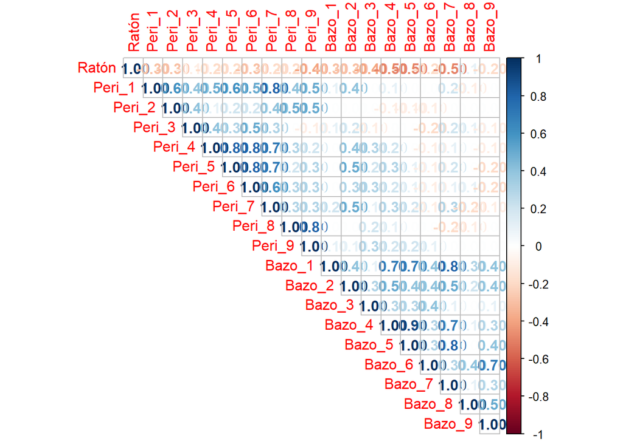

```r
# Para ello se cargan los mismos datos pero agrupados en columnas

folderPathCorrelacion <- c(getwd(),"/","DataBase_PEC3_Ejercicio6.3.csv") ## Leer ruta para cargar base de datos
csvFileCorrelacion <- paste0(folderPathCorrelacion,collapse = "")
dataMurineCorrelacion <- read.csv(csvFileCorrelacion,header = TRUE, sep = ",") ## Introducir datos
dataMurineCorrelacion <- na.omit(dataMurineCorrelacion) #Eliminar valores N/A

dataMurineCorrelacion$Grupo <- NULL # Eliminar para poder hacer la matrix de correlacion
dataMurineCorrelacion$Raton <- NULL # Eliminar para poder hacer la matrix de correlacion


corrplot(round(cor(dataMurineCorrelacion),1),method="number",type = "upper") # Gráfico con matriz de correlacion
```

```r
cat("Las mayores correlaciones se encuentran en la misma region, por ejemplo entre el antigeno 4 y 5 del peritoneo")
```

```
## Las mayores correlaciones se encuentran en la misma region, por ejemplo entre el antigeno 4 y 5 del peritoneo
```

#### 6.4 - La presencia de tumor en los animales modifica la respuesta a los distintos antigenos?

```r
# Se comparan las probabilidades de tener reestimulacion entre los grupos A y B, que pertenecen al mismo tratamiento, y los grupos C y D

# Nuevo data frame para almacenar los resultados
probData <- data.frame()

regionVector <- c("Peritoneo","Bazo") # Regiones posibles

for (i in regionVector){
    for (k in 1:9){

      normFrame <- subset(dataMurine,(dataMurine$Grupo == "A" & dataMurine$Region == Num1[2] & dataMurine$Antigeno == Num1[3]))
      prob1 <- round(1-pnorm(100,mean = mean(normFrame$Reestimulacion),sd = sd(normFrame$Reestimulacion),log = FALSE),4) # Calcular probabilidad de que exista reestimulacion
      normFrame <- subset(dataMurine,(dataMurine$Grupo == "B" & dataMurine$Region == Num1[2] & dataMurine$Antigeno == Num1[3]))
      prob2 <- round(1-pnorm(100,mean = mean(normFrame$Reestimulacion),sd = sd(normFrame$Reestimulacion),log = FALSE),4) # Calcular probabilidad de que exista reestimulacion


      Num1 <- c("Tratamiento_1",i,k,prob1,prob2)
      #print(Num1)
      probData <- rbind(probData,Num1) # Anadir resultado en un base frame junto con los datos de cada muestra
  }
}

for (i in regionVector){
    for (k in 1:9){
      normFrame <- subset(dataMurine,(dataMurine$Grupo == "C" & dataMurine$Region == Num1[2] & dataMurine$Antigeno == Num1[3]))
      prob3 <- round(1-pnorm(100,mean = mean(normFrame$Reestimulacion),sd = sd(normFrame$Reestimulacion),log = FALSE),4) # Calcular probabilidad de que exista reestimulacion
      normFrame <- subset(dataMurine,(dataMurine$Grupo == "D" & dataMurine$Region == Num1[2] & dataMurine$Antigeno == Num1[3]))
      prob4 <- round(1-pnorm(100,mean = mean(normFrame$Reestimulacion),sd = sd(normFrame$Reestimulacion),log = FALSE),4) # Calcular probabilidad de que exista reestimulacion
      Num1 <- c("Tratamiento_2",i,k,prob3,prob4)
      #print(Num1)
      probData <- rbind(probData,Num1) # Anadir resultado en un base frame junto con los datos de cada muestra

  }
}
difference <- c()
for (i in 1:nrow(probData)){
  difference[i] <- as.numeric(probData[i,4])-as.numeric(probData[i,5]) # Calcular la diferencia de cada Antigeno/Region
}
probData$Diferencia <- difference  # Añadir las diferencias entre Reestimulacion del grupo con tumor y sin tumor al Frame

colnames(probData) <- c("Grupo","Region","Antigeno","Prob_Con_Tumor","Prob_Sin_Tumor","Diferencia") # Cambiar nombre de las columnas del Base Frame

cat("Las diferencias entre reestimulaciones de cada grupo se muestran en la siguiente tabla, para aquellos grupos donde la diferencia sea positiva, existe mayor reestimulacion en los grupos con tumor")
```

```
## Las diferencias entre reestimulaciones de cada grupo se muestran en la siguiente tabla, para aquellos grupos donde la diferencia sea positiva, existe mayor reestimulacion en los grupos con tumor
```

```r
probData
```

```
##            Grupo    Region Antigeno Prob_Con_Tumor Prob_Sin_Tumor Diferencia
## 1  Tratamiento_1 Peritoneo        1           <NA>           <NA>         NA
## 2  Tratamiento_1 Peritoneo        2         0.6679         0.2952     0.3727
## 3  Tratamiento_1 Peritoneo        3         0.5434         0.2583     0.2851
## 4  Tratamiento_1 Peritoneo        4           0.62         0.7995    -0.1795
## 5  Tratamiento_1 Peritoneo        5         0.3282         0.5872    -0.2590
## 6  Tratamiento_1 Peritoneo        6         0.3195         0.3467    -0.0272
## 7  Tratamiento_1 Peritoneo        7         0.3885         0.5414    -0.1529
## 8  Tratamiento_1 Peritoneo        8         0.4609         0.6868    -0.2259
## 9  Tratamiento_1 Peritoneo        9         0.8085         0.5995     0.2090
## 10 Tratamiento_1      Bazo        1         0.5362         0.2263     0.3099
## 11 Tratamiento_1      Bazo        2         0.9051         0.6955     0.2096
## 12 Tratamiento_1      Bazo        3         0.7878         0.6688     0.1190
## 13 Tratamiento_1      Bazo        4         0.7737         0.8991    -0.1254
## 14 Tratamiento_1      Bazo        5         0.6967         0.5656     0.1311
```

[output cut: 22 more lines]

## Apartado 7

#### Complementando el apartado anterior, elaborar un análisis ANOVA de dos conjuntos de variables (LAB5 y Ejercicio 6 de la PEC2). La elección de las variables, los resultados, así como su relación deben de estar correctamente justificada. Además, realizar una prueba cluster de las variables, y si existe un fuerte agrupamiento, elaborar un dendograma (LAB5).

### 7.1 - A partir del conjunto de datos dataMurine:

```r
antigeno<-c(dataMurineNumeric$Antigeno)
reestimulacion<-c(dataMurineNumeric$Reestimulacion)
df_murine_anova<-data.frame(antigeno,reestimulacion)
head(df_murine_anova,4) #mostramos la información del data frame
```

```
##   antigeno reestimulacion
## 1        1       87.80488
## 2        1      110.97561
## 3        1       95.01661
## 4        1       81.72757
```

```r
table(df_murine_anova$antigeno) #número de observaciones por cada antigeno
```

```
##
##   1   2   3   4   5   6   7   8   9
## 151 151 151 151 150 150 147 145 145
```

```r
##Media de reestimuación por antigeno de tratamiento
aggregate(reestimulacion~antigeno,data=df_murine_anova,FUN=mean)
```

```
##   antigeno reestimulacion
## 1        1       107.6969
## 2        2       105.3279
## 3        3       117.5266
## 4        4       103.3071
## 5        5       109.4385
## 6        6       109.7597
## 7        7       113.6843
## 8        8       156.8002
## 9        9       114.5797
```

```r
##Desviación típica de reestimulación por antigeno
aggregate(reestimulacion~antigeno,data=df_murine_anova,FUN=sd)
```

```
##   antigeno reestimulacion
## 1        1       25.69121
## 2        2       28.00609
## 3        3       29.57255
## 4        4       25.55474
## 5        5       31.27318
## 6        6       31.55335
## 7        7       37.45681
## 8        8       68.81756
## 9        9       42.71888
```

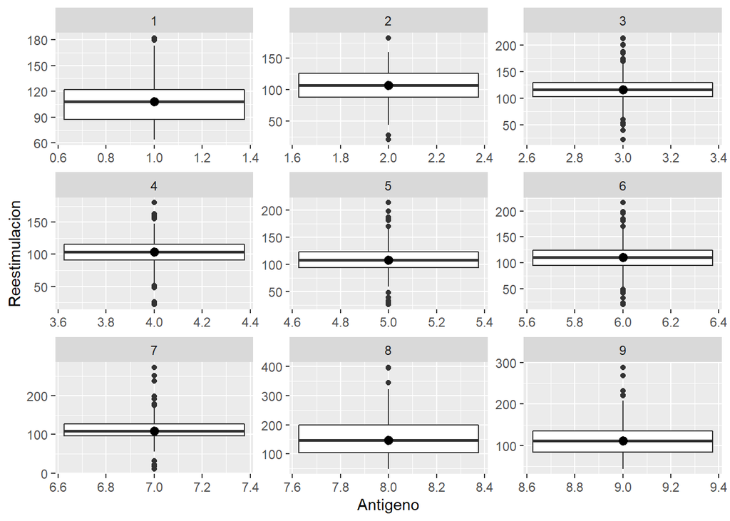

```r
library(ggplot2)

plotMurine <- ggplot(dataMurineNumeric, aes(x=Antigeno, y=Reestimulacion)) +
  geom_boxplot()+stat_summary(fun = median)
plotMurine + facet_wrap( ~ Antigeno, scales="free")
```

- Se observan valores atípicos pero la distribución de los grupos es bastante simétrica

#### 7.1.1 - La variable cuantitativa, en este caso reestimulación, ¿se distribuye de forma normal en cada grupo?

##### Estudio de normalidad

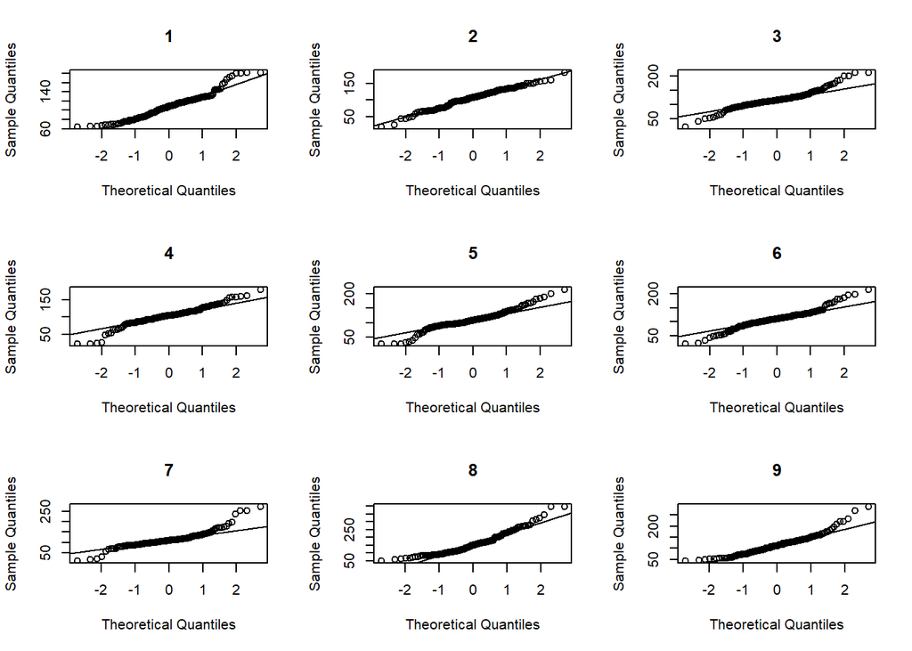

```r
par(mfrow=c(3,3))
qqnorm(df_murine_anova[df_murine_anova$antigeno==1,"reestimulacion"],main=1)
qqline(df_murine_anova[df_murine_anova$antigeno==1,"reestimulacion"])
qqnorm(df_murine_anova[df_murine_anova$antigeno==2,"reestimulacion"],main=2)
qqline(df_murine_anova[df_murine_anova$antigeno==2,"reestimulacion"])
qqnorm(df_murine_anova[df_murine_anova$antigeno==3,"reestimulacion"],main=3)
qqline(df_murine_anova[df_murine_anova$antigeno==3,"reestimulacion"])
qqnorm(df_murine_anova[df_murine_anova$antigeno==4,"reestimulacion"],main=4)
qqline(df_murine_anova[df_murine_anova$antigeno==4,"reestimulacion"])
qqnorm(df_murine_anova[df_murine_anova$antigeno==5,"reestimulacion"],main=5)
qqline(df_murine_anova[df_murine_anova$antigeno==5,"reestimulacion"])
qqnorm(df_murine_anova[df_murine_anova$antigeno==6,"reestimulacion"],main=6)
qqline(df_murine_anova[df_murine_anova$antigeno==6,"reestimulacion"])
qqnorm(df_murine_anova[df_murine_anova$antigeno==7,"reestimulacion"],main=7)
qqline(df_murine_anova[df_murine_anova$antigeno==7,"reestimulacion"])
qqnorm(df_murine_anova[df_murine_anova$antigeno==8,"reestimulacion"],main=8)
qqline(df_murine_anova[df_murine_anova$antigeno==8,"reestimulacion"])
qqnorm(df_murine_anova[df_murine_anova$antigeno==9,"reestimulacion"],main=9)
qqline(df_murine_anova[df_murine_anova$antigeno==9,"reestimulacion"])
```

- A continuación realizaremos un test que acabará de determinar la normalidad de la distribución.Como nuestra muestra es superior a 50 observaciones, utilizamos el test de Kolmogorov-Smirnov.

#### 7.1.2 - Test Kolmogorov-Smirnov

```r
##Instalamos el paquete nortest que contiene las funciones a aplicar
require(nortest)
## Utilizamos dicho paquete sobre el dataframe anterior
by(data=df_murine_anova,INDICES =
df_murine_anova$antigeno,FUN=function(x){lillie.test(x$reestimulacion)})
```

```
## df_murine_anova$antigeno: 1
##
##  Lilliefors (Kolmogorov-Smirnov) normality test
##
## data:  x$reestimulacion
## D = 0.076285, p-value = 0.03162
##
## ------------------------------------------------------------
## df_murine_anova$antigeno: 2
##
##  Lilliefors (Kolmogorov-Smirnov) normality test
##
## data:  x$reestimulacion
## D = 0.076364, p-value = 0.03131
##
## ------------------------------------------------------------
## df_murine_anova$antigeno: 3
##
##  Lilliefors (Kolmogorov-Smirnov) normality test
##
## data:  x$reestimulacion
## D = 0.1048, p-value = 0.0003464
##
## ------------------------------------------------------------
## df_murine_anova$antigeno: 4
##
##  Lilliefors (Kolmogorov-Smirnov) normality test
##
## data:  x$reestimulacion
## D = 0.084663, p-value = 0.01007
##
## ------------------------------------------------------------
## df_murine_anova$antigeno: 5
##
##  Lilliefors (Kolmogorov-Smirnov) normality test
##
## data:  x$reestimulacion
## D = 0.10191, p-value = 0.00063
##
## ------------------------------------------------------------
```

[output cut: 15 more lines]

```
## ------------------------------------------------------------
## df_murine_anova$antigeno: 8
##
##  Lilliefors (Kolmogorov-Smirnov) normality test
##
## data:  x$reestimulacion
## D = 0.099303, p-value = 0.001335
##
## ------------------------------------------------------------
## df_murine_anova$antigeno: 9
##
##  Lilliefors (Kolmogorov-Smirnov) normality test
##
## data:  x$reestimulacion
## D = 0.073745, p-value = 0.0517
```

##### Observamos que la normalidad no es homogenea en todos los grupos ya que el p-value de la mayoria es inferior a 0.05. Solo el grupo *“antigeno 9”* está al limite de aceptar la normalidad.

##### Para evaluar la varianza constante entre los grupos (homocedasticidad) hay diferentes test que podemos aplicar en función de los resultados de normalidad. Al obtener **no normalidad**, utilizamos el test de Fligner-Killeen.

#### 7.1.3 - Test Fligner-Killen

```r
fligner.test(df_murine_anova$reestimulacion~df_murine_anova$antigeno,df_murine_anova)
```

```
##
##  Fligner-Killeen test of homogeneity of variances
##
## data:  df_murine_anova$reestimulacion by df_murine_anova$antigeno
## Fligner-Killeen:med chi-squared = 175.09, df = 8, p-value < 2.2e-16
```

- Se detectan **no homogeneidad de varianzas**

## 7.2 - Estudio ANOVA

```r
anova_murine<-aov(df_murine_anova$reestimulacion~df_murine_anova$antigeno,data=df_murine_anova)
summary(anova_murine)
```

```
##                            Df  Sum Sq Mean Sq F value   Pr(>F)
## df_murine_anova$antigeno    1   79406   79406   50.24 2.19e-12 ***
## Residuals                1339 2116185    1580
## ---
## Signif. codes:  0 '***' 0.001 '**' 0.01 '*' 0.05 '.' 0.1 ' ' 1
```

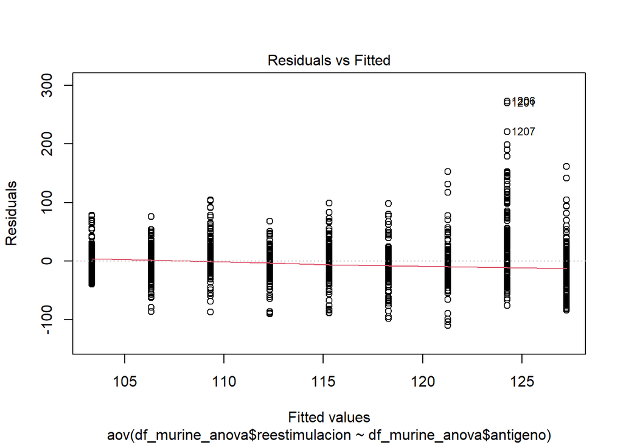

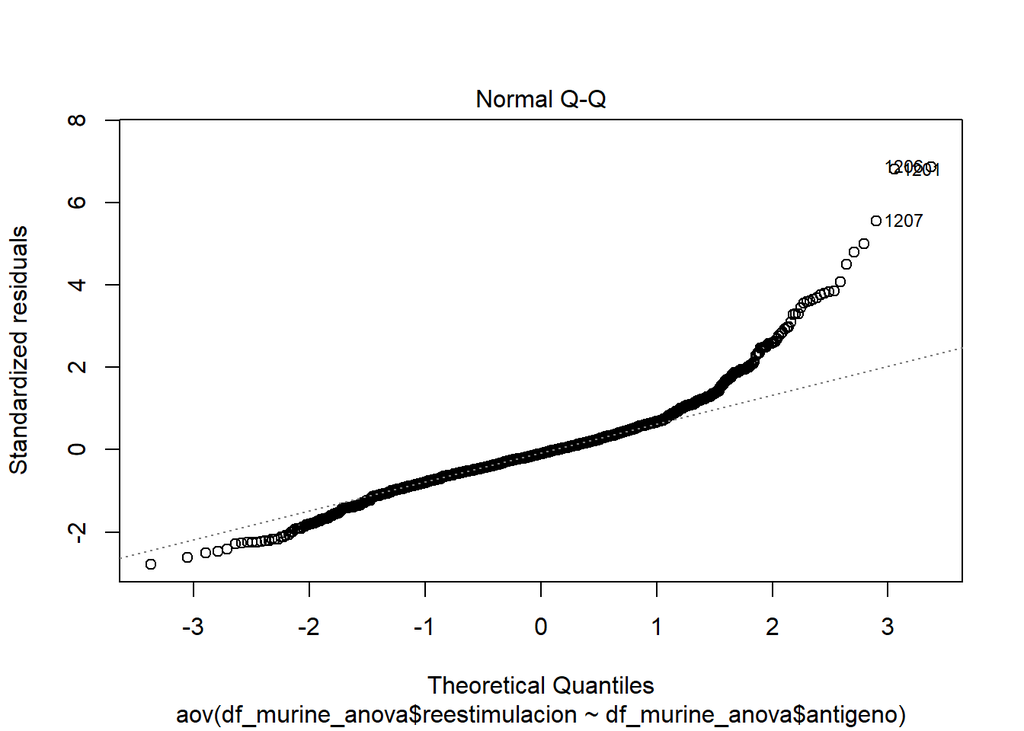

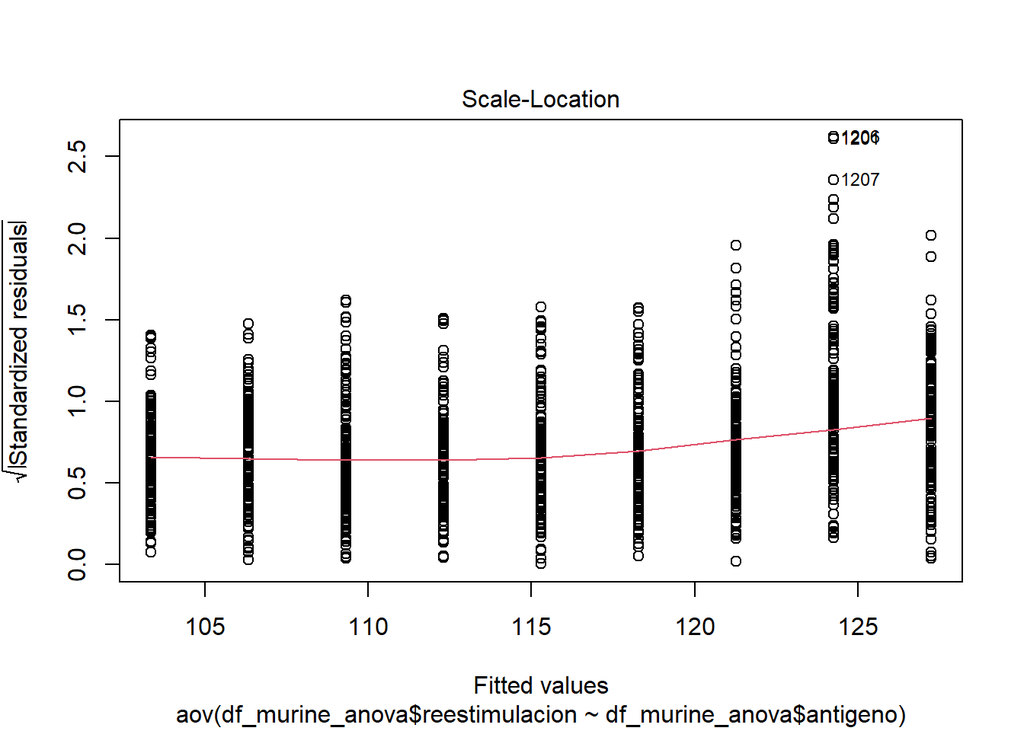

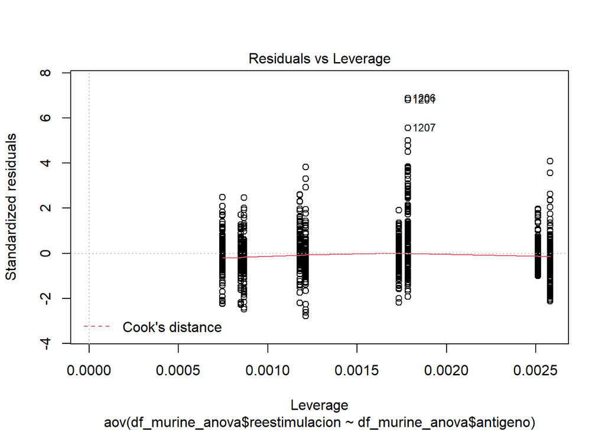

```r
plot(anova_murine)
```

##### Los resultados indican que puede haber **diferencias estadísticamente significativas entre los antigenos utilizados y la reestimulación**, por lo que utilizamos la corrección recomendada *Holm adjustment*

```r
pairwise.t.test(x=df_murine_anova$reestimulacion,g=df_murine_anova$antigeno,p.adjust.method ="holm",pool.sd=TRUE,paired=FALSE,alternative="two.sided")
```

```
##
##  Pairwise comparisons using t tests with pooled SD
##
## data:  df_murine_anova$reestimulacion and df_murine_anova$antigeno
##
##   1      2      3      4      5      6      7      8
## 2 1.00   -      -      -      -      -      -      -
## 3 0.56   0.13   -      -      -      -      -      -
## 4 1.00   1.00   0.03   -      -      -      -      -
## 5 1.00   1.00   1.00   1.00   -      -      -      -
## 6 1.00   1.00   1.00   1.00   1.00   -      -      -
## 7 1.00   1.00   1.00   0.44   1.00   1.00   -      -
## 8 <2e-16 <2e-16 <2e-16 <2e-16 <2e-16 <2e-16 <2e-16 -
## 9 1.00   0.80   1.00   0.26   1.00   1.00   1.00   <2e-16
##
## P value adjustment method: holm
```

## 7.3 - Prueba de clustering/agrupamiento

##### Tomamos como **objetivo la variable Antigeno**

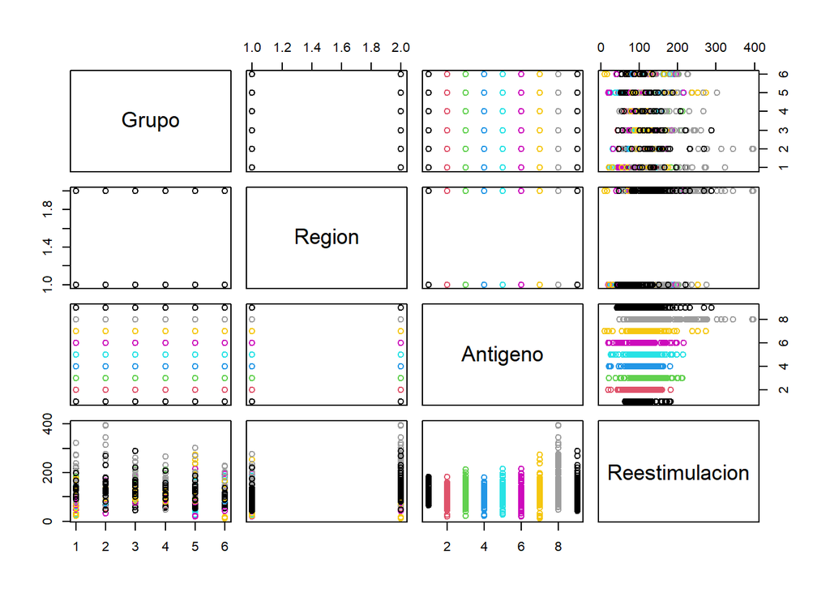

```r
pairs(dataMurineNumeric[2:5],col=dataMurineNumeric$Antigeno)
```

```r
# Comprobamos el grado de correlación entre el resto de variables
cordeg=cor(dataMurineNumeric[2:5])
cordeg
```

```
##                      Grupo       Region     Antigeno Reestimulacion
## Grupo           1.00000000 -0.156525810 -0.005310840    -0.07926643
## Region         -0.15652581  1.000000000  0.002792134     0.30722088
## Antigeno       -0.00531084  0.002792134  1.000000000     0.19017387
## Reestimulacion -0.07926643  0.307220878  0.190173866     1.00000000
```

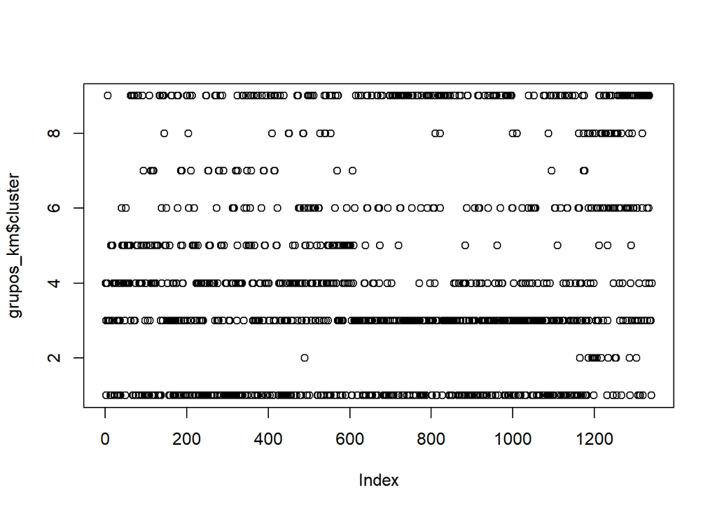

```r
##Construimos los grupos de clústeres, crearemos 9  grupos que son los tipos de antigeno (*Antigeno*)

grupos_km=kmeans(dataMurineNumeric[2:5],9)
plot(grupos_km$cluster)
```

##### Tras observar el anterior plot podemos decir que no se aprecia un fuerte agrupamiento, por tanto no se procede con la elaboración del dendrograma

## Apartado 8

#### 8.1 - La mayor correlacion de reestimulacion entre antigenos se encuentran en la misma region, estos son del mismo tipo y responden a los mismos factores.

```
##        Ratón Peri_1 Peri_2 Peri_3 Peri_4 Peri_5 Peri_6 Peri_7 Peri_8 Peri_9
## Ratón   1.00  -0.28  -0.35  -0.13  -0.21  -0.24  -0.25  -0.24  -0.20  -0.40
## Peri_1 -0.28   1.00   0.64   0.41   0.46   0.64   0.46   0.75   0.39   0.47
## Peri_2 -0.35   0.64   1.00   0.37   0.15   0.17   0.20   0.39   0.48   0.54
## Peri_3 -0.13   0.41   0.37   1.00   0.36   0.32   0.46   0.34  -0.02  -0.05
## Peri_4 -0.21   0.46   0.15   0.36   1.00   0.82   0.80   0.70   0.31   0.21
## Peri_5 -0.24   0.64   0.17   0.32   0.82   1.00   0.84   0.75   0.22   0.30
## Peri_6 -0.25   0.46   0.20   0.46   0.80   0.84   1.00   0.60   0.27   0.25
## Peri_7 -0.24   0.75   0.39   0.34   0.70   0.75   0.60   1.00   0.31   0.30
## Peri_8 -0.20   0.39   0.48  -0.02   0.31   0.22   0.27   0.31   1.00   0.78
## Peri_9 -0.40   0.47   0.54  -0.05   0.21   0.30   0.25   0.30   0.78   1.00
## Bazo_1 -0.30   0.06  -0.01   0.13   0.00   0.05   0.00   0.20   0.02   0.15
## Bazo_2 -0.34   0.40   0.01   0.22   0.37   0.45   0.30   0.46   0.04   0.14
## Bazo_3 -0.44   0.02  -0.01  -0.12   0.25   0.22   0.26   0.10   0.17   0.32
## Bazo_4 -0.51   0.14  -0.15  -0.05   0.17   0.27   0.20   0.33   0.10   0.15
## Bazo_5 -0.52   0.04  -0.09   0.03   0.03   0.12   0.07   0.20   0.04   0.17
## Bazo_6 -0.21   0.03  -0.07  -0.16  -0.09  -0.08  -0.12  -0.07   0.02   0.06
## Bazo_7 -0.50   0.16  -0.04   0.21   0.11   0.18   0.10   0.30  -0.16   0.03
## Bazo_8  0.07  -0.05   0.00   0.05  -0.02   0.00   0.06  -0.16  -0.08  -0.05
## Bazo_9 -0.22  -0.01   0.00  -0.13  -0.10  -0.19  -0.22  -0.06   0.00  -0.03
##        Bazo_1 Bazo_2 Bazo_3 Bazo_4 Bazo_5 Bazo_6 Bazo_7 Bazo_8 Bazo_9
## Ratón   -0.30  -0.34  -0.44  -0.51  -0.52  -0.21  -0.50   0.07  -0.22
## Peri_1   0.06   0.40   0.02   0.14   0.04   0.03   0.16  -0.05  -0.01
## Peri_2  -0.01   0.01  -0.01  -0.15  -0.09  -0.07  -0.04   0.00   0.00
## Peri_3   0.13   0.22  -0.12  -0.05   0.03  -0.16   0.21   0.05  -0.13
## Peri_4   0.00   0.37   0.25   0.17   0.03  -0.09   0.11  -0.02  -0.10
## Peri_5   0.05   0.45   0.22   0.27   0.12  -0.08   0.18   0.00  -0.19
## Peri_6   0.00   0.30   0.26   0.20   0.07  -0.12   0.10   0.06  -0.22
## Peri_7   0.20   0.46   0.10   0.33   0.20  -0.07   0.30  -0.16  -0.06
## Peri_8   0.02   0.04   0.17   0.10   0.04   0.02  -0.16  -0.08   0.00
## Peri_9   0.15   0.14   0.32   0.15   0.17   0.06   0.03  -0.05  -0.03
## Bazo_1   1.00   0.40   0.14   0.68   0.74   0.36   0.75   0.31   0.44
## Bazo_2   0.40   1.00   0.30   0.48   0.43   0.39   0.53   0.18   0.40
## Bazo_3   0.14   0.30   1.00   0.27   0.27   0.39   0.11   0.01   0.14
## Bazo_4   0.68   0.48   0.27   1.00   0.85   0.31   0.73   0.05   0.30
## Bazo_5   0.74   0.43   0.27   0.85   1.00   0.27   0.80  -0.01   0.36
## Bazo_6   0.36   0.39   0.39   0.31   0.27   1.00   0.27   0.41   0.70
## Bazo_7   0.75   0.53   0.11   0.73   0.80   0.27   1.00   0.10   0.34
## Bazo_8   0.31   0.18   0.01   0.05  -0.01   0.41   0.10   1.00   0.51
## Bazo_9   0.44   0.40   0.14   0.30   0.36   0.70   0.34   0.51   1.00
```

```
##            Grupo    Region Antigeno Prob_Con_Tumor Prob_Sin_Tumor Diferencia
## 1  Tratamiento_1 Peritoneo        1           <NA>           <NA>         NA
## 2  Tratamiento_1 Peritoneo        2         0.6679         0.2952     0.3727
## 3  Tratamiento_1 Peritoneo        3         0.5434         0.2583     0.2851
## 4  Tratamiento_1 Peritoneo        4           0.62         0.7995    -0.1795
## 5  Tratamiento_1 Peritoneo        5         0.3282         0.5872    -0.2590
## 6  Tratamiento_1 Peritoneo        6         0.3195         0.3467    -0.0272
## 7  Tratamiento_1 Peritoneo        7         0.3885         0.5414    -0.1529
## 8  Tratamiento_1 Peritoneo        8         0.4609         0.6868    -0.2259
## 9  Tratamiento_1 Peritoneo        9         0.8085         0.5995     0.2090
## 10 Tratamiento_1      Bazo        1         0.5362         0.2263     0.3099
## 11 Tratamiento_1      Bazo        2         0.9051         0.6955     0.2096
## 12 Tratamiento_1      Bazo        3         0.7878         0.6688     0.1190
## 13 Tratamiento_1      Bazo        4         0.7737         0.8991    -0.1254
## 14 Tratamiento_1      Bazo        5         0.6967         0.5656     0.1311
```

[output cut: 22 more lines]

#### 8.3 - Tras un estudio de regresión, podemos concluir que:

- Los antígenos tienen un impacto importante en cuanto a la reestimulación de macrófagos

```r
summary(murine_rm)
```

```
##
## Call:
## lm(formula = dataMurineNumeric$Reestimulacion ~ dataMurineNumeric$Region +
##     dataMurineNumeric$Antigeno, data = dataMurineNumeric[2:5])
##
## Residuals:
##     Min      1Q  Median      3Q     Max
## -121.99  -21.09   -5.09   14.49  261.71
##
## Coefficients:
##                            Estimate Std. Error t value Pr(>|t|)
## (Intercept)                 61.9101     3.9024  15.865   <2e-16 ***
## dataMurineNumeric$Region    24.9212     2.0718  12.029   <2e-16 ***
## dataMurineNumeric$Antigeno   2.9750     0.4007   7.425    2e-13 ***
## ---
## Signif. codes:  0 '***' 0.001 '**' 0.01 '*' 0.05 '.' 0.1 ' ' 1
##
## Residual standard error: 37.78 on 1338 degrees of freedom
## Multiple R-squared:  0.1302, Adjusted R-squared:  0.1289
## F-statistic: 100.2 on 2 and 1338 DF,  p-value: < 2.2e-16
```

#### 8.4 - Tras un estudio ANOVA y de clustering de las variables, podemos concluir que:

- Puede haber **diferencias estadísticamente significativas entre los antigenos utilizados y la reestimulación**. Necesitariamos utilizar el *Holm adjustment* para corregir lo mas posible dichas diferencias.

```
##
##  Pairwise comparisons using t tests with pooled SD
##
## data:  df_murine_anova$reestimulacion and df_murine_anova$antigeno
##
##   1      2      3      4      5      6      7      8
## 2 1.00   -      -      -      -      -      -      -
## 3 0.56   0.13   -      -      -      -      -      -
## 4 1.00   1.00   0.03   -      -      -      -      -
## 5 1.00   1.00   1.00   1.00   -      -      -      -
## 6 1.00   1.00   1.00   1.00   1.00   -      -      -
## 7 1.00   1.00   1.00   0.44   1.00   1.00   -      -
## 8 <2e-16 <2e-16 <2e-16 <2e-16 <2e-16 <2e-16 <2e-16 -
## 9 1.00   0.80   1.00   0.26   1.00   1.00   1.00   <2e-16
##
## P value adjustment method: holm
```

- No se encuentran agrupamientos claros en cuanto a clustering

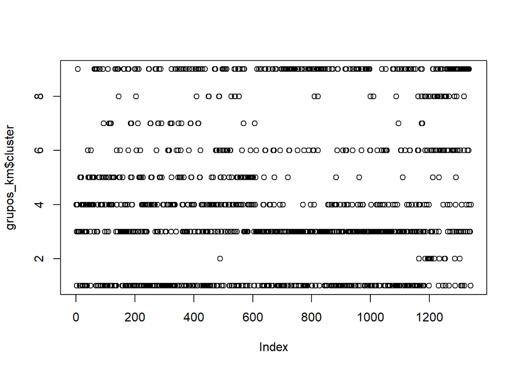